# Data Science Challenge

```python
# To install packages that are not installed by default, uncomment the last two lines
# of this cell and replace <package list> with a list of necessary packages.
# This will ensure the notebook has all the dependencies and works everywhere.
#! pip install -U imbalanced-learn
import sys
!{sys.executable} -m pip install -U imbalanced-learn
```

[output not shown]

```python
!{sys.executable} -m pip install scikit-learn==0.22.2
```

[output not shown]

## Business Problem:

Find hotels based on early availability

```python
import pandas as pd
import numpy as np
import seaborn as sns
import matplotlib.pyplot as plt
%matplotlib inline
from sklearn.metrics import recall_score
from sklearn.metrics import precision_score
from sklearn.metrics import accuracy_score
from sklearn.model_selection import train_test_split
from scipy import stats

import warnings
warnings.filterwarnings('ignore')
```

```python
#Libraries
import pandas as pd
import numpy as np
pd.set_option("display.max_columns", 101)
```

## Data Description

| Column | Description |
| --- | --- |
| `id` | The unique ID assigned to every hotel. |
| `region` | The region in which the hotel is located.. |
| `latitude` | The latitude of the hotel. |
| `longitude` | The longitude of the hotel. |
| `accommodation_type` | The type of accommodation offered by the hotel. For example: Private room, Entire house/apt, etc. |
| `cost` | The cost of booking the hotel for one night. (in \$\$) |
| `minimum_nights` | The minimum number of nights stay required. |
| `number_of_reviews` | The number of reviews accumulated by the hotel. |
| `reviews_per_month` | The average number of reviews received by the hotel per month. |
| `owner_id` | The unique ID assigned to every owner. An owner can own multiple hotels. |
| `owned_hotels` | The number of hotels owned by the owner. |
| `yearly_availability` | It indicates if the hotel accepts bookings around the year. Values are 0 (not available for 365 days in a year) and 1 (available for 365 days in a year). |

## Data Wrangling & Visualization

```python
# Dataset is already loaded below
data = pd.read_csv("train.csv")
```

```python
print("There are {:,} observations and {} columns in the data set.".format(data.shape[0], data.shape[1]))
print("There are {} missing values in the data.".format(data.isna().sum().sum()))
```

```
There are 2,870 observations and 12 columns in the data set.
There are 676 missing values in the data.
```

```python
# Simple Exploration
```

```python
data.head()
```

|  | id | region | latitude | longitude | accommodation_type | cost | minimum_nights | number_of_reviews | reviews_per_month | owner_id | owned_hotels | yearly_availability |
| --- | --- | --- | --- | --- | --- | --- | --- | --- | --- | --- | --- | --- |
| 0 | 13232 | Manhattan | 40.71854 | -74.00439 | Entire home/apt | 170 | 5 | 7 | 0.56 | 929983 | 1 | 0 |
| 1 | 246 | Brooklyn | 40.64446 | -73.95030 | Entire home/apt | 65 | 3 | 238 | 2.30 | 281764 | 1 | 0 |
| 2 | 19091 | Queens | 40.78573 | -73.81062 | Private room | 85 | 1 | 0 | NaN | 19923341 | 1 | 1 |
| 3 | 34305 | Manhattan | 40.73863 | -73.98002 | Private room | 210 | 30 | 0 | NaN | 200380610 | 65 | 1 |
| 4 | 444 | Manhattan | 40.82426 | -73.94630 | Shared room | 75 | 3 | 38 | 0.42 | 745069 | 3 | 1 |

```python
display(data.sample(5))
```

|  | id | region | latitude | longitude | accommodation_type | cost | minimum_nights | number_of_reviews | reviews_per_month | owner_id | owned_hotels | yearly_availability |
| --- | --- | --- | --- | --- | --- | --- | --- | --- | --- | --- | --- | --- |
| 2654 | 45774 | Staten Island | 40.58647 | -74.15954 | Entire home/apt | 68 | 2 | 8 | 5.33 | 258232863 | 1 | 0 |
| 1160 | 14566 | Manhattan | 40.75066 | -73.97037 | Private room | 198 | 30 | 0 | NaN | 2856748 | 49 | 1 |
| 1810 | 19436 | Brooklyn | 40.67749 | -73.94386 | Private room | 99 | 180 | 4 | 0.12 | 6218023 | 1 | 1 |
| 2553 | 9281 | Manhattan | 40.72348 | -73.99095 | Shared room | 250 | 1 | 0 | NaN | 37170055 | 1 | 0 |
| 2819 | 45461 | Queens | 40.76268 | -73.82252 | Shared room | 99 | 1 | 10 | 5.77 | 151810361 | 6 | 1 |

```python
#Explore columns
data.columns
```

```
Index(['id', 'region', 'latitude', 'longitude', 'accommodation_type', 'cost',
       'minimum_nights', 'number_of_reviews', 'reviews_per_month', 'owner_id',
       'owned_hotels', 'yearly_availability'],
      dtype='object')
```

```python
# count the number of rows for each type of our target varible
data.groupby('yearly_availability').size()
```

```
yearly_availability
0    1439
1    1431
dtype: int64
```

```python
#Description
data.describe()
```

|  | id | latitude | longitude | cost | minimum_nights | number_of_reviews | reviews_per_month | owner_id | owned_hotels | yearly_availability |
| --- | --- | --- | --- | --- | --- | --- | --- | --- | --- | --- |
| count | 2870.000000 | 2870.000000 | 2870.000000 | 2870.000000 | 2870.000000 | 2870.000000 | 2194.000000 | 2.870000e+03 | 2870.000000 | 2870.000000 |
| mean | 26760.657143 | 40.731224 | -73.950158 | 195.943206 | 11.530314 | 16.315331 | 1.157502 | 7.202195e+07 | 8.411498 | 0.498606 |
| std | 14140.930062 | 0.054942 | 0.049745 | 406.184714 | 37.972339 | 32.481722 | 1.355028 | 8.076516e+07 | 27.105522 | 0.500085 |
| min | 0.000000 | 40.507080 | -74.242850 | 10.000000 | 1.000000 | 0.000000 | 0.010000 | 2.787000e+03 | 1.000000 | 0.000000 |
| 25% | 15931.750000 | 40.692462 | -73.984003 | 75.000000 | 1.000000 | 1.000000 | 0.240000 | 7.388002e+06 | 1.000000 | 0.000000 |
| 50% | 28946.500000 | 40.728250 | -73.956720 | 120.000000 | 3.000000 | 4.000000 | 0.650000 | 3.352708e+07 | 1.000000 | 0.000000 |
| 75% | 38478.500000 | 40.762658 | -73.934202 | 200.000000 | 6.000000 | 16.000000 | 1.530000 | 1.207625e+08 | 3.000000 | 1.000000 |
| max | 48893.000000 | 40.898730 | -73.721730 | 9999.000000 | 999.000000 | 395.000000 | 10.370000 | 2.738123e+08 | 327.000000 | 1.000000 |

From the analysis above we can examine that the highest cost is 9999 assuming its in dollars, the maverage cost of overall regions is $195.

There are hotels with a min cost of $10. There are hotels that have no reviews as well. There is an owner that holds 327 hotels.

```python
#Description
data.describe(include = 'object')
```

|  | region | accommodation_type |
| --- | --- | --- |
| count | 2870 | 2870 |
| unique | 5 | 3 |
| top | Manhattan | Private room |
| freq | 1333 | 1225 |

From the above table we can exmaine that the categorial features accommodation_type has the higest in Private rooms giving an impression that private rooms might be most in demand, while region highest is Manhattan

```python
# Total missing values for each feature
print(data.isnull().sum())
```

```
id                       0
region                   0
latitude                 0
longitude                0
accommodation_type       0
cost                     0
minimum_nights           0
number_of_reviews        0
reviews_per_month      676
owner_id                 0
owned_hotels             0
yearly_availability      0
dtype: int64
```

## Visualization, Modeling, Machine Learning

Build a model that categorizes hotels on the basis of their yearly availability. Identify how different features influence the decision. Please explain the findings effectively to technical and non-technical audiences using comments and visualizations, if appropriate.

- **Build an optimized model that effectively solves the business problem.**
- **The model will be evaluated on the basis of Accuracy.**
- **Read the test.csv file and prepare features for testing.**

## EDA

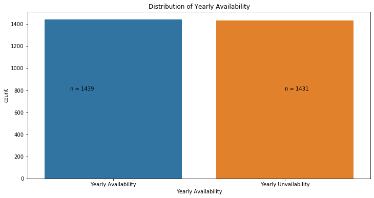

```python
labels = ['Yearly Availability',
         'Yearly Unvailability']
fig, ax = plt.subplots(figsize=(12,6)) # create bigger plot
_ = sns.countplot(data.yearly_availability) #count plot
_ = ax.set_xlabel('Yearly Availability')
_ = ax.set_xticklabels(labels)
_ = plt.title('Distribution of Yearly Availability')
_ = plt.text(s = f"n = {data.yearly_availability.value_counts()[0]}", x = -0.25, y = 800) #placing count number
_ = plt.text(s = f"n = {data.yearly_availability.value_counts()[1]}", x = 1, y = 800)
```

#### Correlation plot

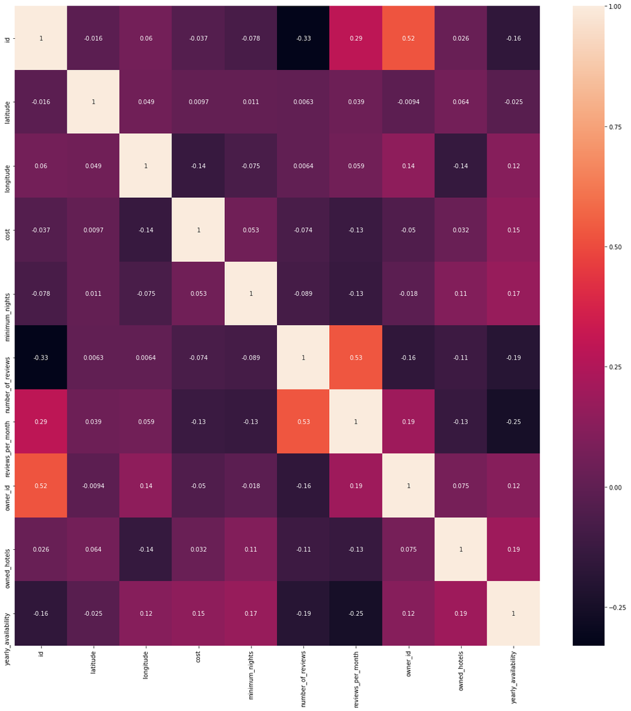

```python
plt.figure(figsize=(20,20))
corr = data.corr()
sns.heatmap(corr, annot=True)
```

From the correlation plot we can analyze that as our y varibles is yearly availability, it doesnt have any strongly positive correlations, most correlations are weak less than 0.2. The highest corrrelation we examine is between number of reviews vs reviews per month. This is beacuse of genreal domain knowadge and understanding that each review count is given in months.

As the information is correlated, there might be Multi-collinearity issue for with we will remove one.We will also remove Ids features and lat long features are make no contributions towards yearly available, lat long is removed also beacuse we have region varible that gives us information about the location

As we are dealing with yearly predictions, we can review monthly reviews count as we also have a total of all the reviews in another column.

We can analyze how cost and number of reviews

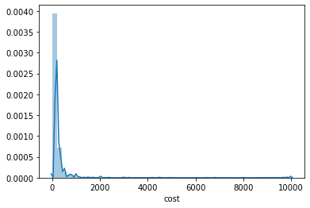

```python
sns.distplot(data['cost'])
```

We can exmaine the cost distribution is positive skewed.

In terms of analysis, we can do our analysis upon yearly availabilty, how each features in combination as well effects its disributions

```
Figuring out each regions cost, with respect to thier yearly availablity.
```

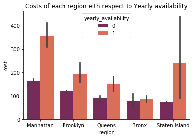

```python
sns.barplot(x="region", y="cost", hue="yearly_availability", data=data, palette="rocket").set_title('Costs of each region eith respect to Yearly availability')
```

```
What is the average cost per region:
```

```python
data.groupby('region')['cost'].mean()
```

```
region
Bronx             82.461538
Brooklyn         151.576744
Manhattan        257.604651
Queens           125.891892
Staten Island    215.214286
Name: cost, dtype: float64
```

```
In I have more time left, I will come back to this section and do more EDAs in terms of
- Which owned hotels have the highest yearly availablity
        - which region had the highest availablty  with respect to
        - What is the average cost of hotels per region
                - We know that more availaibity means more reviews, how much would less yearly unavaility impact of social performace based due to the reviews.
```

```python
data.groupby('region')['number_of_reviews'].max()
```

```
region
Bronx            122
Brooklyn         309
Manhattan        395
Queens           209
Staten Island     20
Name: number_of_reviews, dtype: int64
```

Although Bronx has low cost and low availabity but still it might have happy customers as 122 reviews are given.

```python
data.loc[(data['accommodation_type'] == 'Private room') & (data['minimum_nights'] > 4)]
```

|  | id | region | latitude | longitude | accommodation_type | cost | minimum_nights | number_of_reviews | reviews_per_month | owner_id | owned_hotels | yearly_availability |
| --- | --- | --- | --- | --- | --- | --- | --- | --- | --- | --- | --- | --- |
| 3 | 34305 | Manhattan | 40.73863 | -73.98002 | Private room | 210 | 30 | 0 | NaN | 200380610 | 65 | 1 |
| 5 | 30553 | Manhattan | 40.73976 | -74.00953 | Private room | 200 | 10 | 11 | 0.76 | 11243113 | 1 | 1 |
| 9 | 2673 | Queens | 40.76781 | -73.92684 | Private room | 70 | 20 | 75 | 1.05 | 7676839 | 1 | 1 |
| 12 | 22760 | Manhattan | 40.72948 | -74.00961 | Private room | 195 | 30 | 1 | 0.25 | 22541573 | 87 | 1 |
| 15 | 45327 | Manhattan | 40.72757 | -73.98336 | Private room | 150 | 31 | 0 | NaN | 261589968 | 1 | 1 |
| ... | ... | ... | ... | ... | ... | ... | ... | ... | ... | ... | ... | ... |
| 2844 | 1426 | Manhattan | 40.73727 | -74.00213 | Private room | 700 | 5 | 1 | 0.01 | 3198479 | 1 | 1 |
| 2847 | 23695 | Queens | 40.70507 | -73.90195 | Private room | 55 | 30 | 2 | 0.10 | 133802988 | 6 | 1 |
| 2851 | 16832 | Manhattan | 40.76207 | -73.99937 | Private room | 239 | 30 | 0 | NaN | 30283594 | 121 | 1 |
| 2860 | 43233 | Manhattan | 40.74250 | -73.99443 | Private room | 260 | 29 | 0 | NaN | 219517861 | 327 | 1 |
| 2868 | 16757 | Manhattan | 40.74637 | -73.97207 | Private room | 200 | 30 | 0 | NaN | 2856748 | 49 | 1 |

493 rows × 12 columns

We can exmaine that private room is in high demand but the minium number of nights required to stay more in these, stateing the tourists or people that would want to come on just weekends (< 4 -5 ) days cant be accomodated here.

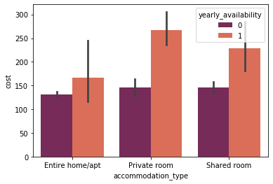

```python
sns.barplot(x="accommodation_type", y="cost", hue="yearly_availability", data=data, palette="rocket")
```

### Dealing with imbalance of yearly availaibilty - with clasS_weight = 'balance'

```python
data.columns
```

```
Index(['id', 'region', 'latitude', 'longitude', 'accommodation_type', 'cost',
       'minimum_nights', 'number_of_reviews', 'reviews_per_month', 'owner_id',
       'owned_hotels', 'yearly_availability'],
      dtype='object')
```

```python
#extracting features types
drop_list = ['id', 'latitude', 'longitude', 'owner_id','reviews_per_month']
numeric_features = [ 'cost', 'minimum_nights', 'number_of_reviews', 'owned_hotels']
cat_features = [ 'region', 'accommodation_type']

data.drop(drop_list,inplace = True,axis=1)
```

```python
data.columns #verify drop
```

```
Index(['region', 'accommodation_type', 'cost', 'minimum_nights',
       'number_of_reviews', 'owned_hotels', 'yearly_availability'],
      dtype='object')
```

### Dealing with null values in reviews col

```python
#dealing with null values of reviews

data.fillna(data.mean()) #replacing number of reviews with mean()
```

|  | region | accommodation_type | cost | minimum_nights | number_of_reviews | owned_hotels | yearly_availability |
| --- | --- | --- | --- | --- | --- | --- | --- |
| 0 | Manhattan | Entire home/apt | 170 | 5 | 7 | 1 | 0 |
| 1 | Brooklyn | Entire home/apt | 65 | 3 | 238 | 1 | 0 |
| 2 | Queens | Private room | 85 | 1 | 0 | 1 | 1 |
| 3 | Manhattan | Private room | 210 | 30 | 0 | 65 | 1 |
| 4 | Manhattan | Shared room | 75 | 3 | 38 | 3 | 1 |
| ... | ... | ... | ... | ... | ... | ... | ... |
| 2865 | Manhattan | Private room | 400 | 2 | 0 | 1 | 1 |
| 2866 | Manhattan | Private room | 180 | 3 | 2 | 1 | 1 |
| 2867 | Manhattan | Entire home/apt | 179 | 3 | 17 | 1 | 0 |
| 2868 | Manhattan | Private room | 200 | 30 | 0 | 49 | 1 |
| 2869 | Manhattan | Shared room | 1000 | 30 | 24 | 11 | 1 |

2870 rows × 7 columns

We donot want to remove those na rows as we will lose alot of information.

### feature engineering

```python
print('Number accomdation types:', data.accommodation_type.nunique())
data.groupby('accommodation_type').size().sort_values(ascending = False)
```

```
Number accomdation types: 3
```

```
accommodation_type
Private room       1225
Entire home/apt    1002
Shared room         643
dtype: int64
```

```python
print('Number Region types:', data.region.nunique())
data.groupby('region').size().sort_values(ascending = False)
```

```
Number Region types: 5
```

```
region
Manhattan        1333
Brooklyn         1075
Queens            370
Bronx              78
Staten Island      14
dtype: int64
```

```python
data.region.unique()
```

```
array(['Manhattan', 'Brooklyn', 'Queens', 'Bronx', 'Staten Island'],
      dtype=object)
```

As we will create dummy varibles for our categories, one catgory region type has Staten Island and Bronx being the least as compared to the other three. While creating dummy varibles there will be alot created with these 2 in addition cause high dimenstionaity in data which migh cause problems in our models, hence will try to keep low dimenstions and make a varible named 'other' and combine these two

```python
top_3 = ['Manhattan', 'Brooklyn', 'Queens']

# replace all specialties not in top 10 with 'Other' category
data.loc[~data.region.isin(top_3),'region'] = 'Other'

data.region.unique() #verify
```

```
array(['Manhattan', 'Brooklyn', 'Queens', 'Other'], dtype=object)
```

```python
finaldata = pd.get_dummies(data, columns = cat_features) #OneHot Encoding of catgorial varibles
```

```python
finaldata.info()
```

```
<class 'pandas.core.frame.DataFrame'>
RangeIndex: 2870 entries, 0 to 2869
Data columns (total 12 columns):
cost                                  2870 non-null int64
minimum_nights                        2870 non-null int64
number_of_reviews                     2870 non-null int64
owned_hotels                          2870 non-null int64
yearly_availability                   2870 non-null int64
region_Brooklyn                       2870 non-null uint8
region_Manhattan                      2870 non-null uint8
region_Other                          2870 non-null uint8
region_Queens                         2870 non-null uint8
accommodation_type_Entire home/apt    2870 non-null uint8
accommodation_type_Private room       2870 non-null uint8
accommodation_type_Shared room        2870 non-null uint8
dtypes: int64(5), uint8(7)
memory usage: 131.9 KB
```

```python
finaldata.head(2)
```

|  | cost | minimum_nights | number_of_reviews | owned_hotels | yearly_availability | region_Brooklyn | region_Manhattan | region_Other | region_Queens | accommodation_type_Entire home/apt | accommodation_type_Private room | accommodation_type_Shared room |
| --- | --- | --- | --- | --- | --- | --- | --- | --- | --- | --- | --- | --- |
| 0 | 170 | 5 | 7 | 1 | 0 | 0 | 1 | 0 | 0 | 1 | 0 | 0 |
| 1 | 65 | 3 | 238 | 1 | 0 | 1 | 0 | 0 | 0 | 1 | 0 | 0 |

```python
#spliting the cols for yearly avail vs rest features to be used
X = finaldata.drop('yearly_availability',axis=1)
y = finaldata['yearly_availability']
```

```python
X.shape #verifying shape for safe side
```

```
(2870, 11)
```

```python
y.shape
```

```
(2870,)
```

```python
X_train, X_val, y_train, y_val =train_test_split(X, y, test_size=0.20, random_state=45) #use validation as test set given
```

```python
from sklearn.preprocessing import StandardScaler
ss = StandardScaler() #susing StandardScale
X_train = ss.fit_transform(X_train)
X_val = ss.transform(X_val)
```

For our model building we will start will intial models that are simple as they are more parsimonious. Due to time constraints and limited memory constraints (slow), I will just perform 3 models on which further will hyper tunning if required.

```python
#intial methods for code reuseability

def modelFitResults(modelsList,dictionary_models):
    '''This method will be call for each model perform fit and return list of metrics for all model recall accuracy testing and training'''

    recall_performance_={} #dic for evalution mertics
    accuracy_val={}
    accuracy_train={}
    pipemodels= {} #if we have tomuse them further for safe side

    for i,pipe in enumerate(simpleModelPipelines):
        pipemodels[dictionary_models[i]]=pipe.fit(X_train,y_train) #calling fit on model pipelines

        #saving evalutions in dictionary for Data Analysis
        recall_performance_[dictionary_models[i]]= recall_score(y_val,pipe.predict(X_val),average='weighted')
        accuracy_val[dictionary_models[i]]= accuracy_score(y_val,pipe.predict(X_val))
        accuracy_train[dictionary_models[i]]= accuracy_score(y_train,pipe.predict(X_train))

        print('Metrics For ' + dictionary_models[i])
        measure_performance(X_val, y_val, pipe,show_confussion_matrix=False)

    return recall_performance_,accuracy_val,accuracy_train,pipemodels #return all
```

```python
def plot(dicOne,dicTwo,metricName,label1,label2):
    '''bar plot'''
    x = np.arange(len(dicOne))

    width = 0.3
    metric_name = metricName
    val_dicOne = [v for v in dicOne.values()]
    val_dicTwo = [v for v in dicTwo.values()] #getting values from dictionarys
    plt.ylabel(label1+'-'+label2)
    plt.bar(x - 0.17, val_dicOne, width, label=label1) #adding space
    plt.bar(x + 0.17, val_dicTwo, width, label=label2)

    plt.xticks(ticks=x, labels=dicOne.keys(),
               rotation=45) #rotating ticks as they wont fit properly
    _ = plt.legend()
```

```python
def dictionaryToSeries(dictionary):
    '''returns series for the eval metrics stored in dictionary '''
    return (pd.Series(dictionary,index=dictionary.keys()))
```

```python
from sklearn import metrics

def measure_performance(X_val, y_val, clf, show_accuracy=True, show_classification_report=True, show_confussion_matrix=True):
    y_pred = clf.predict(X_val)
    if show_accuracy:
         print ("Accuracy:{0:.3f}".format(metrics.accuracy_score(y_val, y_pred)),"\n") #show accuracy

    if show_classification_report:
        print ("Classification report")
        print (metrics.classification_report(y_val, y_pred),"\n") #show report

    if show_confussion_matrix:
        print ("Confussion matrix")
        plot_confusion_matrix(clf, X_val, y_val) #show matrix
```

```python
# Plot the confusion matrix at the end of the tutorial
from sklearn.metrics import plot_confusion_matrix
# Classification Models
from sklearn.linear_model import LogisticRegression
from sklearn.neighbors import KNeighborsClassifier
from sklearn.ensemble import RandomForestClassifier
from sklearn.tree import DecisionTreeClassifier
```

```python
knn = KNeighborsClassifier() #simplest model
lr = LogisticRegression(class_weight='balanced') #good for binary classficiation - Lets see!
rf = RandomForestClassifier(class_weight='balanced') #ensemble teq (combine multiple DT might give good results)

simpleModelPipelines = [knn,lr,rf]

grid_dict_simple = {0: 'KNN',1: 'Logistic Regression',2:'RF'}

recall_performance_ ,accuracy_val ,accuracy_train,models = modelFitResults(simpleModelPipelines,grid_dict_simple)
```

```
Metrics For KNN
Accuracy:0.909

Classification report
              precision    recall  f1-score   support

           0       0.91      0.91      0.91       293
           1       0.90      0.91      0.91       281

    accuracy                           0.91       574
   macro avg       0.91      0.91      0.91       574
weighted avg       0.91      0.91      0.91       574


Metrics For Logistic Regression
Accuracy:0.873

Classification report
              precision    recall  f1-score   support

           0       0.88      0.86      0.87       293
           1       0.86      0.88      0.87       281

    accuracy                           0.87       574
   macro avg       0.87      0.87      0.87       574
weighted avg       0.87      0.87      0.87       574


Metrics For RF
Accuracy:0.936

Classification report
              precision    recall  f1-score   support

           0       0.94      0.93      0.94       293
           1       0.93      0.94      0.93       281

    accuracy                           0.94       574
   macro avg       0.94      0.94      0.94       574
weighted avg       0.94      0.94      0.94       574
```

```python
#measure_performance(X_val, y_val, rf,show_accuracy=False, show_classification_report=False)
```

So far our best model is Random Forest

```python
#Lets visualize it

AccuracyTrainIntialModels =dictionaryToSeries(accuracy_train) #covert for plot
AccuracyTestIntialModels =dictionaryToSeries(accuracy_val)
RecallOfModels = dictionaryToSeries(recall_performance_)
```

```python
print('Training Accuracy')
print(AccuracyTrainIntialModels)
```

```
Training Accuracy
KNN                    0.920296
Logistic Regression    0.867160
RF                     0.999129
dtype: float64
```

```python
print('Testing Accuracy')
print(AccuracyTestIntialModels)
```

[output not shown]

```python
print('Recall')
print(RecallOfModels)
```

[output not shown]

```
dict_values([0.9094076655052264, 0.872822299651568, 0.9337979094076655])
```

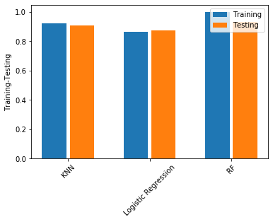

```python
plot(accuracy_train,accuracy_val ,'Accuracy','Training','Testing')
recall_performance_.values()
```

From the vizualtion as well we can examine that the highest is Random Forest, however it has overfitiing as training accuracy is 99% while testing accuracy is 93% we will deal with that as well

as the compiler runs very slow on grid or random search, I am using just the highest accuracy model to hyper tunning if making tweaks to imporve it more.

```python
param_range = [1, 2, 3, 4, 5, 6]
# Minimum number of samples required to split a node
min_samples_split = [2, 5, 10]
# Minimum number of samples required at each leaf node
min_samples_leaf = [1, 2, 4]
from sklearn.model_selection import StratifiedKFold
skf = StratifiedKFold(n_splits=10, shuffle=True, random_state=1)


rf_param_grid = [{'min_samples_leaf': min_samples_split,
                   'max_depth': param_range,
                   'min_samples_split': min_samples_leaf}]
```

```python
from sklearn.model_selection import RandomizedSearchCV #accuracy score is given as a business metric, njobs = -1 to make multiple concurrent processing for faster eval
searchRF = RandomizedSearchCV(rf, rf_param_grid, n_iter=50, scoring='accuracy', n_jobs=-1, cv=skf, random_state=1)
```

```python
searchRF.fit(X_train,y_train)
searchRF.best_estimator_ #getting best estimators to make use to it for model
```

```
RandomForestClassifier(bootstrap=True, ccp_alpha=0.0, class_weight='balanced',
                       criterion='gini', max_depth=5, max_features='auto',
                       max_leaf_nodes=None, max_samples=None,
                       min_impurity_decrease=0.0, min_impurity_split=None,
                       min_samples_leaf=2, min_samples_split=4,
                       min_weight_fraction_leaf=0.0, n_estimators=100,
                       n_jobs=None, oob_score=False, random_state=None,
                       verbose=0, warm_start=False)
```

```python
measure_performance(X_train, y_train, searchRF,show_confussion_matrix=False) #training to check overfitting or not
```

```
Accuracy:0.923

Classification report
              precision    recall  f1-score   support

           0       0.94      0.90      0.92      1146
           1       0.90      0.95      0.92      1150

    accuracy                           0.92      2296
   macro avg       0.92      0.92      0.92      2296
weighted avg       0.92      0.92      0.92      2296
```

```python
measure_performance(X_val, y_val, searchRF,show_confussion_matrix=False)
```

```
Accuracy:0.939

Classification report
              precision    recall  f1-score   support

           0       0.95      0.92      0.94       293
           1       0.92      0.95      0.94       281

    accuracy                           0.94       574
   macro avg       0.94      0.94      0.94       574
weighted avg       0.94      0.94      0.94       574
```

We can exmaine that with hyper tunning parameters, the over-fititng is gone, intally with no hyper tunning parameters we has an overfitting of 7%, but now the training accuracy is been dropped down to 92 percent, and our validation accuracy is 93%, there is 1% of underfitting, but there is always a trade off between bias and varience.

#### Final Model choosen as Random Forest with Hyper tunning Parameters with a Recall of 0.95, and accuracy of 93%

```python
#Loading Test data
test_data=pd.read_csv('test.csv')
test_date_id = test_data['id'] #save id for predictions
test_data.head()
```

|  | id | region | latitude | longitude | accommodation_type | cost | minimum_nights | number_of_reviews | reviews_per_month | owner_id | owned_hotels |
| --- | --- | --- | --- | --- | --- | --- | --- | --- | --- | --- | --- |
| 0 | 19215 | Brooklyn | 40.70912 | -73.94513 | Shared room | 135 | 2 | 22 | 0.66 | 4360212 | 1 |
| 1 | 36301 | Brooklyn | 40.57646 | -73.96641 | Entire home/apt | 69 | 2 | 8 | 0.90 | 181356989 | 2 |
| 2 | 40566 | Manhattan | 40.76616 | -73.98228 | Private room | 225 | 30 | 0 | NaN | 13773574 | 12 |
| 3 | 33694 | Manhattan | 40.77668 | -73.94587 | Shared room | 125 | 30 | 9 | 0.82 | 6788748 | 1 |
| 4 | 28873 | Manhattan | 40.80279 | -73.94450 | Entire home/apt | 43 | 1 | 13 | 0.72 | 105061915 | 2 |

```python
test_data.isna().sum()
```

```
id                      0
region                  0
latitude                0
longitude               0
accommodation_type      0
cost                    0
minimum_nights          0
number_of_reviews       0
reviews_per_month     173
owner_id                0
owned_hotels            0
dtype: int64
```

```python
test_data.fillna(test_data.mean()) #replacing number of reviews with mean()
test_data.drop(drop_list,inplace = True,axis=1)
```

```python
top_3 = ['Manhattan', 'Brooklyn', 'Queens']

# replace all specialties not in top 10 with 'Other' category
test_data.loc[~test_data.region.isin(top_3),'region'] = 'Other'
```

```python
test_data.region.nunique()
```

```
4
```

```python
finaldata_test = pd.get_dummies(test_data, columns = cat_features) #OneHot Encoding of catgorial varibles
```

```python
finaldata_test.info()
```

```
<class 'pandas.core.frame.DataFrame'>
RangeIndex: 718 entries, 0 to 717
Data columns (total 11 columns):
cost                                  718 non-null int64
minimum_nights                        718 non-null int64
number_of_reviews                     718 non-null int64
owned_hotels                          718 non-null int64
region_Brooklyn                       718 non-null uint8
region_Manhattan                      718 non-null uint8
region_Other                          718 non-null uint8
region_Queens                         718 non-null uint8
accommodation_type_Entire home/apt    718 non-null uint8
accommodation_type_Private room       718 non-null uint8
accommodation_type_Shared room        718 non-null uint8
dtypes: int64(4), uint8(7)
memory usage: 27.5 KB
```

```python
ss = StandardScaler() #susing StandardScale
X_test = ss.fit_transform(finaldata_test) # standerized
```

```python
predictions = searchRF.predict(X_test)
```

```python
#test_data.isna().sum() #verify
```

**Highlight the most important features of the model for management.**

#### Task:

> - **Visualize the top 20 features and their feature importance.**

```python
feature_list = list(X.columns)
# get importance
importance = list(searchRF.best_estimator_.feature_importances_)
feature_importance = [(feature, round(importance,2)) for feature, importance in zip (feature_list, importance)]
[print('variable:{:25} Importance:{}'.format(*pair)) for pair in feature_importance]
```

```
variable:cost                      Importance:0.02
variable:minimum_nights            Importance:0.04
variable:number_of_reviews         Importance:0.07
variable:owned_hotels              Importance:0.16
variable:region_Brooklyn           Importance:0.0
variable:region_Manhattan          Importance:0.0
variable:region_Other              Importance:0.0
variable:region_Queens             Importance:0.0
variable:accommodation_type_Entire home/apt Importance:0.24
variable:accommodation_type_Private room Importance:0.37
variable:accommodation_type_Shared room Importance:0.08
```

```
[None, None, None, None, None, None, None, None, None, None, None]
```

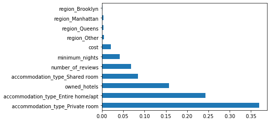

```python
(pd.Series(searchRF.best_estimator_.feature_importances_, index=X.columns).nlargest(20).plot(kind='barh'))
```

We exmained from the model accommodation types plays the most important role in our, especially private room with 37%, we inffered this through our data analysis as well. After private room is followed by entire apartment by 24%. The lowest input is from regions, one reason could be that we have less data for each region but the model tells us the Brooklyn has the least importance while as other is a combination of two is has more importance than Queens, however Queen was more in number count than Staten Island and Bronx (that we combined)

#### Task:

> - **Submit the predictions on the test dataset using your optimized model**  
>   For each record in the test set (`test.csv`), predict the value of the `yearly_availability` variable. Submit a CSV file with a header row and one row per test entry.

The file (`submissions.csv`) should have exactly 2 columns:

- **id**
- **yearly_availability**

```python
submission_df = pd.DataFrame(predictions)
submission_df['id'] = test_date_id
```

```python
submission_df
```

|  | 0 | id |
| --- | --- | --- |
| 0 | 0 | 19215 |
| 1 | 0 | 36301 |
| 2 | 1 | 40566 |
| 3 | 0 | 33694 |
| 4 | 0 | 28873 |
| ... | ... | ... |
| 713 | 0 | 26801 |
| 714 | 0 | 20110 |
| 715 | 0 | 31383 |
| 716 | 1 | 47135 |
| 717 | 1 | 13154 |

718 rows × 2 columns

```python
# columns_titles = ["0","id"]
# submission_df=submission_df.reindex(columns=columns_titles)
```

```python
#Submission
submission_df.to_csv('submissions.csv',header=['yearly_availability','id'],index=False)
```

### Final Analysis and Conlusion:

From our analysis and machine learning model, we can conlude that we can deploy this model for Travel Express as it has a 93% accuracy, hotels should focus on more private room accomdations and entire apartments making more yearly availablity, Ownders (Owner ids) should open more in regions like Staten Island and Bronx and accomodations.

### Further Improvement and Analysis that could be done in feature:

-We can implement pipelines, that results is good code reuseabilty as well is less memory leaks while making predictions on testing data.

-Accuracy can be improved more with incorperating hyper tunning with other parameters,

-More Stronger Classification ensemble learning tec can be incorperated to improve accuracy and recall.